# Task 2: Lizard Length to Weight NLS

Nick McManus

2023-02-19

```r
knitr::opts_chunk$set(echo = TRUE, message=FALSE, warning=FALSE)
library(tidyverse)  #always
library(broom)      #tidy tables
library(kableExtra) #pretty tables
library(Metrics)    #rmse fxn
```

# Introduction

In this task, we use non-linear least squares (NLS) to estimate parameters of snout length to weight model for lizard populations in New Mexico. Then, an NLS model is fitted to a subset of the data containing only observations for male Western Whiptail lizards (*Cnemidophorus tigrisatus*). This species-specific NLS model is compared against the general model to determine the effect of datasets on NLS model fit. Lizard data used for this task was collected using pitfall traps at the Jornada Basin long-term ecological research site between 1989-2006.

**Source:** Lightfoot, D. and W.G. Whitford. 2020. Lizard pitfall trap data from 11 NPP study locations at the Jornada Basin LTER site, 1989-2006 ver 37. Environmental Data Initiative. https://doi.org/10.6073/pasta/4a6e258fb49c31e222ecbbcfd128967f

```r
lizards <- read_csv("lizards.csv") %>%
  #remove pesky captilized letters
  janitor::clean_names()
```

# 1. Select model

The first step in NLS is selecting a model that best fits the data. After searching through the literature (i.e. this task assignment), we’ve decided to fit snouth length to lizard weight using the following model:
$$W=a(SVL)^b$$
where W is lizard weight (g) and SVL is snout to vent length (mm). Unfortunately, this model is not yet complete, as $a$ and $b$ are parameters that need to be fitted!

```r
# create a function based on model
fxn <- function(a, b, svl){
 weight <- a*(svl^b)
return(weight)
}
```

# 2. Initial Guess

Once we have a model starting point, we can start toward constructing our NLS with sufficient guesses. Because our model is incomplete and exponential, we’ll first need to log transform it and complete a standard ordinary least squares (OLS) regression on the equation. This will provide close-enough approximations of the parameters to then perform our NLS.

```r
# OLS regression on log-transformed model
my_guess_model <- lm(log(lizards$weight) ~ log(lizards$sv_length), data = lizards)

# OLS regression coefficients
#coefficients(my_guess_model)

# asign guesses for parameters a and b
a <- exp((my_guess_model$coefficients[1]))
b <- my_guess_model$coefficients[2]
```

# 3. Run NLS

Now that we have initial guesses for parameters $a$ and $b$, we can run our NLS using the dataset and model. With the results, we can display how well the model fits the data.

```r
# run NLS
lizards_nls <- nls(weight ~ fxn(a, b, sv_length),
                   data = lizards,
                   start = list(a = a, b = b))

# return results in tidy table
lizards_nls_tidy <- tidy(lizards_nls)
lizards_nls_tidy %>%
  kable(caption = "**Table 1.** NLS results.",
        col.names = c("Parameter", "Coefficient", "Standard error", "Statistic", "p-value")) %>%
  kable_styling(full_width = FALSE,
                bootstrap_options = "hover",
                position = "left")
```

**Table 1.** NLS results.

| Parameter | Coefficient | Standard error | Statistic | p-value |
| --- | --- | --- | --- | --- |
| a | 0.0001073 | 0.0000091 | 11.77374 | 0 |
| b | 2.7209866 | 0.0196796 | 138.26425 | 0 |

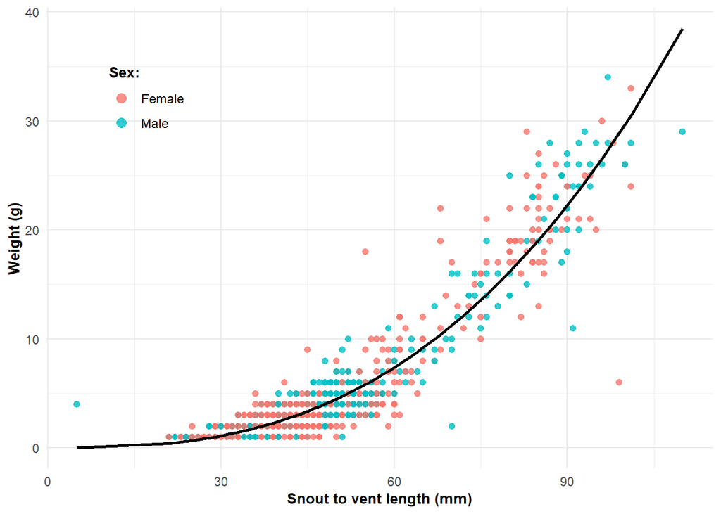

```r
# predict weight based on model
lizards_pred <- lizards %>%
  mutate(predict = predict(lizards_nls, newdata=.))


# plot how well prediction matches
ggplot(data = lizards_pred) +
  #points for actual obs
  geom_point(aes(x = sv_length, y = weight, color = sex),
             size = 1.8,
             alpha = 0.8) +
  scale_color_manual(values = c("coral", "dodgerblue3")) +
  scale_color_discrete(labels = c('Female', 'Male')) +
  #line for predictions
  geom_line(aes(x = sv_length , y = predict),
            color='black',
            size = 1) +
  labs(x = 'Snout to vent length (mm)',
       y = 'Weight (g)') +
  theme_minimal() +
  theme(
    #legend
    legend.position = c(0.15, 0.8),
    legend.title = element_text(size = 10, face = 'bold'),
    legend.text = element_text(size = 9),
    #axes
    axis.title.x = element_text(size = 10, face = 'bold'),
    axis.title.y = element_text(size = 10, face = 'bold')) +
  guides(colour = guide_legend(override.aes = list(size = 3), title = "Sex:"))
```

**Fig 1.** Snout to vent lengths (mm) and body weights (g) for male and female lizards observed at the Jornada Basin LTER. Female observations are indicated in coral, while male observations are indicated with blue points. The NLS predicted model of weight as a function of snout vent length is indicated by the black line and has a root mean squared error (RMSE) of 1.563 g.

# NLS for *C. tigrisatus*

Now an NLS model will be fitted to a subset of lizard observations only of male *C. tigrisatus*.

```r
### STEP 1: create data subset ----------------------------
lizards_cnti <- lizards %>%
  filter(spp == 'CNTI',
         sex == 'M')

### STEP 2: Initial guess ---------------------------------
# OLS regression on log-transformed model
my_guess_model_cnti <- lm(log(lizards_cnti$weight) ~ log(lizards_cnti$sv_length),
                          data = lizards_cnti)

# OLS regression coefficients
#coefficients(my_guess_model_cnti)

# assign guesses for parameters a and b
a_cnti <- exp((my_guess_model_cnti$coefficients[1]))
b_cnti <- my_guess_model_cnti$coefficients[2]

### STEP 3: Run NLS --------------------------------------
# run NLS
lizards_cnti_nls <- nls(weight ~ fxn(a, b, sv_length),
                        data = lizards_cnti,
                        start = list(a = a_cnti, b = b_cnti))

# return results in tidy table
lizards_cnti_nls_tidy <- tidy(lizards_cnti_nls)
lizards_cnti_nls_tidy %>%
  kable(caption = "**Table 2.** NLS results for male *C. tigrisatus*.",
        col.names = c("Parameter", "Coefficient",
                      "Standard error", "Statistic", "p-value")) %>%
  kable_styling(full_width = FALSE,
                bootstrap_options = "hover",
                position = "left")
```

**Table 2.** NLS results for male *C. tigrisatus*.

| Parameter | Coefficient | Standard error | Statistic | p-value |
| --- | --- | --- | --- | --- |
| a | 0.0005316 | 0.0004288 | 1.239686 | 0.2192313 |
| b | 2.3683014 | 0.1800348 | 13.154689 | 0.0000000 |

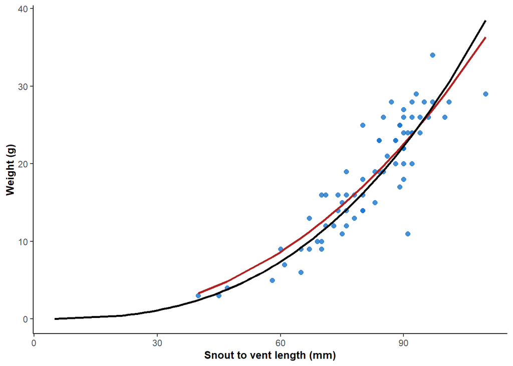

```r
# predict weight based on model
lizards_cnti_pred <- lizards_cnti %>%
  mutate(predict = predict(lizards_cnti_nls, newdata=.))

# RMSE for predictions
lizards_rmse <- data.frame(rmse_cnti = rmse(lizards_cnti_pred$weight,
                                            lizards_cnti_pred$predict),
                           rmse_cnti_v_gen = rmse(lizards_cnti_pred$weight,
                                                  lizards_pred$predict),
                           rmse_gen = rmse(lizards_pred$weight,
                                           lizards_pred$predict))

# plot how well prediction matches for CNTI and all lizards
ggplot() +
  #points for actual obs
  geom_point(data = lizards_cnti_pred,
             aes(x = sv_length, y = weight),
             size = 2,
             color = 'dodgerblue3',
             alpha = 0.8) +
  #line for CNTI predictions
  geom_line(data = lizards_cnti_pred,
            aes(x = sv_length , y = predict),
            color='firebrick',
            size = 1) +
  #line for general predicitons
  geom_line(data = lizards_pred,
            aes(x = sv_length , y = predict),
            color='black',
            size = 1) +
  labs(x = 'Snout to vent length (mm)',
       y = 'Weight (g)') +
  theme_classic() +
  theme(
    axis.title.x = element_text(size = 10, face = 'bold'),
    axis.title.y = element_text(size = 10, face = 'bold'))
```